# Week 11 Day 2 Homework

```r
library(rpart)
library(rpart.plot)
library(tidyverse)
library(janitor)
library(tidyverse)

titanic_set <- read_csv('data/titanic_decision_tree_data.csv')
shuffle_index <- sample(1:nrow(titanic_set))

# shuffle the data so class order isn't in order - need this for training/testing split later on
# this isn't changing anything in the data its just changing order of rows
titanic_set <- titanic_set[shuffle_index, ]
```

# 1 MVP

## 1.1 Question 1

```r
titanic_clean <- titanic_set %>%
  filter(survived %in% c(0,1)) %>%
# Convert to factor level
    mutate(sex = as.factor(sex),
           age_status = as.factor(if_else(age <= 16, "child", "adult")),
         class = factor(pclass, levels = c(3,2,1), labels = c("Lower", "Middle", "Upper")),
           survived_flag = factor(survived, levels = c(0,1), labels = c("No", "Yes")),
           port_embarkation = as.factor(embarked)) %>%
  select(sex, age_status, class, port_embarkation, sib_sp, parch, survived_flag) %>%
  na.omit()
```

## 1.2 Question 2

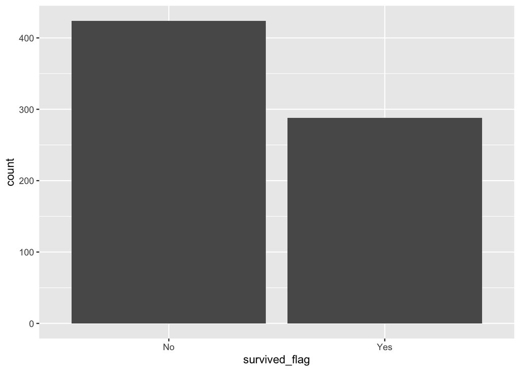

```r
ggplot(titanic_clean, aes(survived_flag)) +
  geom_bar()
```

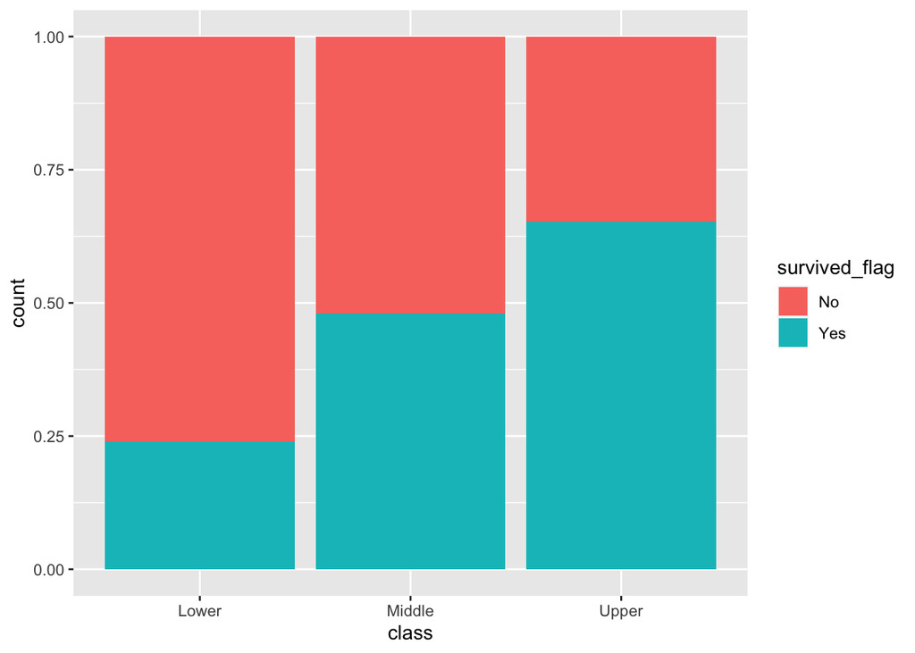

```r
ggplot(titanic_clean, aes(class, fill = survived_flag)) +
  geom_bar(position = "fill")
```

This plot above tells us that the higher the class of passenger, the more likely they were to survive. Over 75% over lower class passengers died. Class will likely be an important variable.

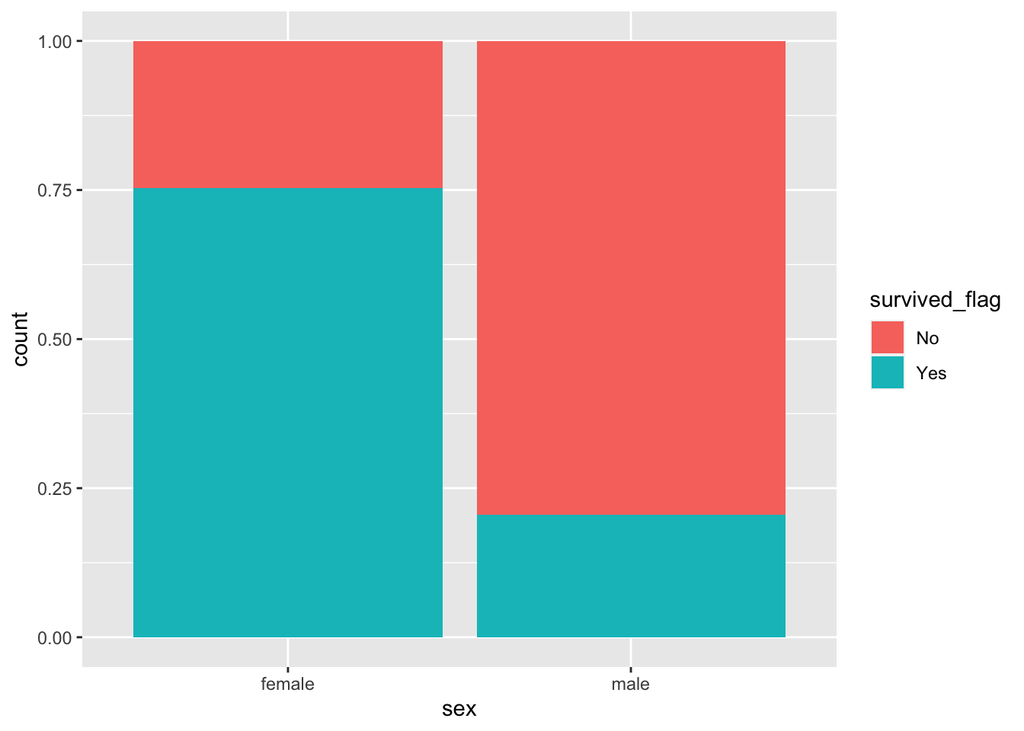

```r
ggplot(titanic_clean, aes(sex, fill = survived_flag)) +
  geom_bar(position = "fill")
```

A much larger proportion of men died, compared to woman so sex is likely to be an important variable as well.

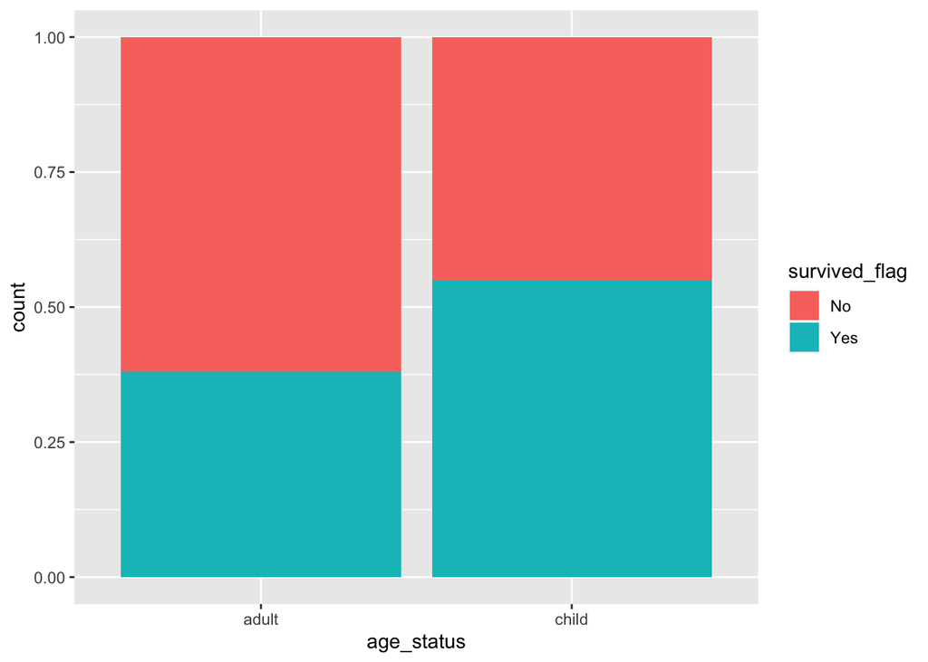

```r
ggplot(titanic_clean, aes(age_status, fill = survived_flag)) +
  geom_bar(position = "fill")
```

A higher proportion of children than adults survived but the difference in proportion isn’t as high as for class and sex.

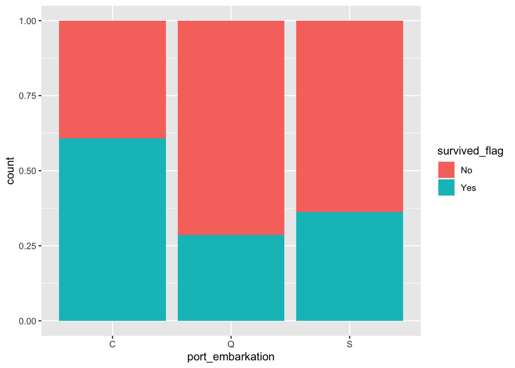

```r
ggplot(titanic_clean, aes(port_embarkation, fill = survived_flag)) +
  geom_bar(position = "fill")
```

A much higher porportion of people survived if they embarked at Cherbourg. I wonder if this might be related to class though?

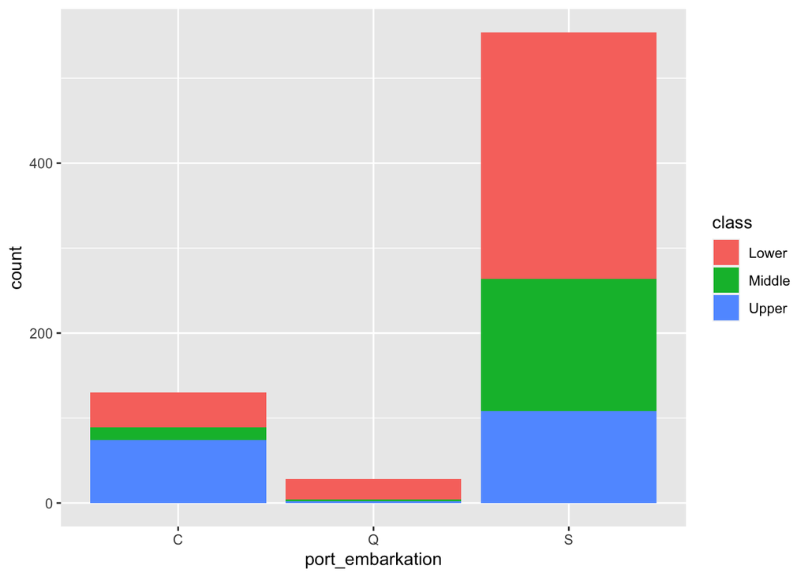

```r
ggplot(titanic_clean, aes(port_embarkation, fill = class)) +
  geom_bar()
```

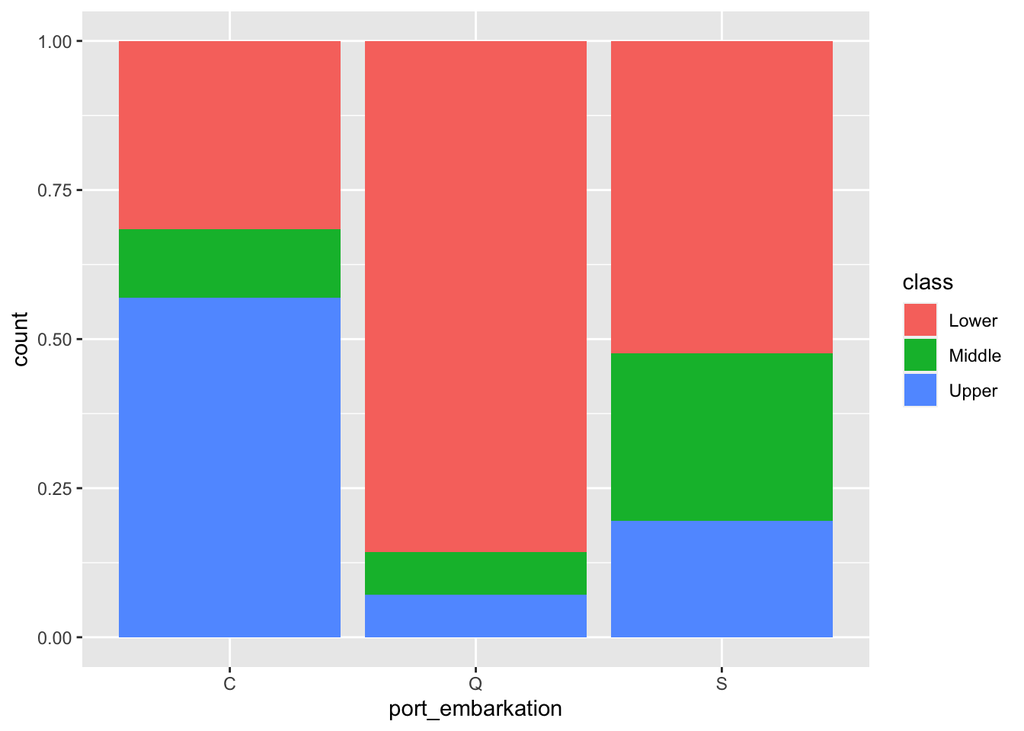

```r
ggplot(titanic_clean, aes(port_embarkation, fill = class)) +
  geom_bar(position = "fill")
```

Cherbourg has the highest proportion of upper class passenger so it may be a proxy for class. Will have to watch out for that.

I would expect the sibsp and parch number to be related to the chance of survival. I think people in family groups would be more likely to survive than e.g. single men.

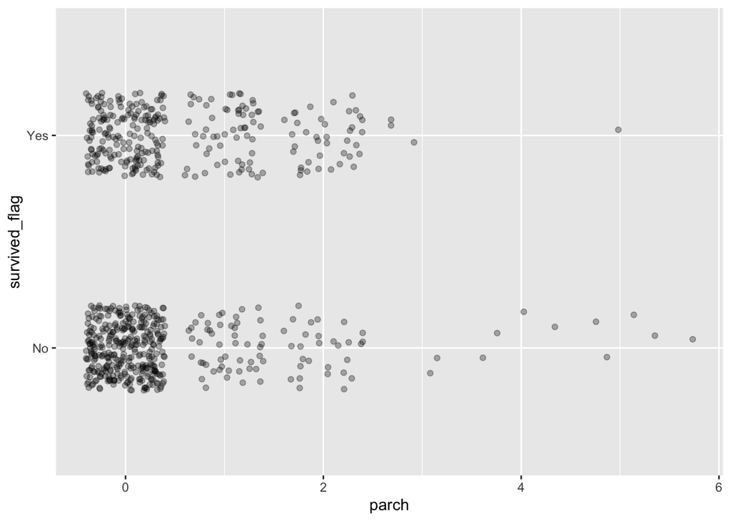

```r
ggplot(titanic_clean, aes(parch, survived_flag)) +
  geom_jitter(height = 0.2, alpha = 0.3)
```

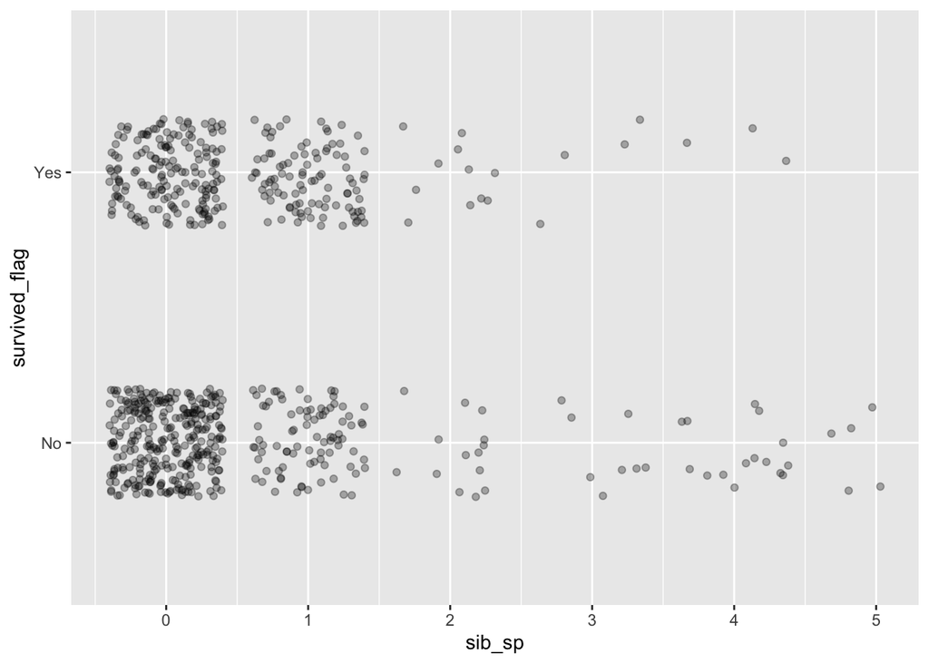

```r
ggplot(titanic_clean, aes(sib_sp, survived_flag)) +
  geom_jitter(height = 0.2, alpha = 0.3)
```

## 1.3 Question 3

```r
n_data <- nrow(titanic_clean)

test_index <- sample(1:n_data, size = n_data * 0.2)

titanic_test <- slice(titanic_clean, test_index)

titanic_train <- slice(titanic_clean, -test_index)
```

Checking properties of both data sets

```r
titanic_train %>%
  tabyl(survived_flag)
```

| survived_flag | n | percent |
| --- | --- | --- |
| No | 337 | 0.5912281 |
| Yes | 233 | 0.4087719 |

```r
titanic_test %>%
  tabyl(survived_flag)
```

| survived_flag | n | percent |
| --- | --- | --- |
| No | 87 | 0.6126761 |
| Yes | 55 | 0.3873239 |

An 80:20 split was chosen as this is a decent sized dataset so 20% of observations in the test set will give us decent results. 80:20 is a commonly used split and I see no reason to choose anything else.

The train and test datasets are split quite evenly on survival so I am happy the train and test sets are balanced.

## 1.4 Question 4

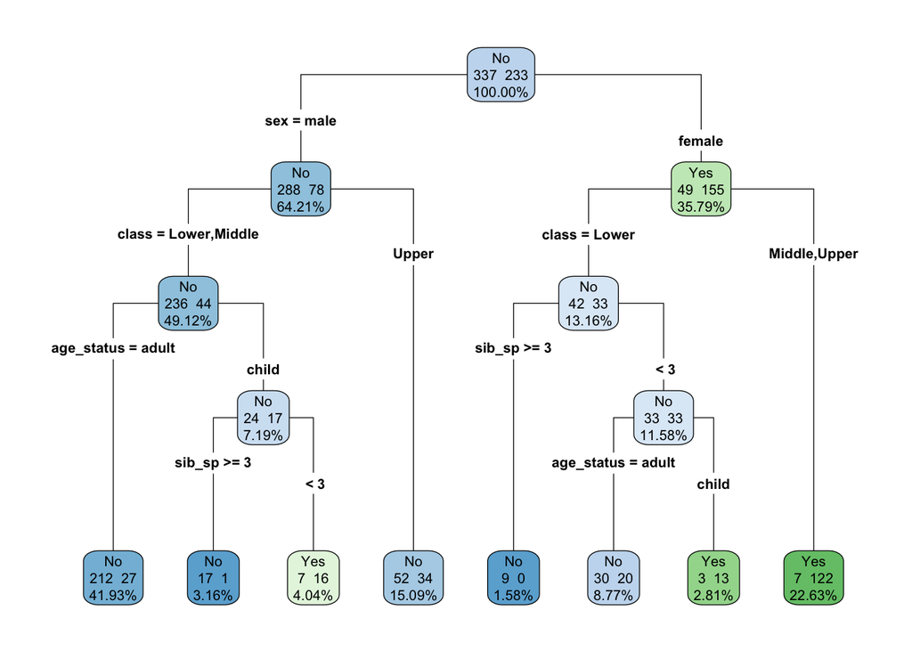

```r
titanic_fit <- rpart(
  formula = survived_flag ~ .,
  data = titanic_train,
  method = "class"
)

rpart.plot(titanic_fit,
           yesno = 2,
           fallen.leaves = TRUE,
           faclen = 6,
           digits = 4,
           type = 4,
           extra = 101)
```

## 1.5 Question 5

These are the most informative for predicting whether someone died or not on the titanic.

```r
rpart.rules(titanic_fit, cover = TRUE)
```

|  | survived_flag |  |  |  |  |  |  |  |  |  |  |  |  |  |  |  |  | cover |
| --- | --- | --- | --- | --- | --- | --- | --- | --- | --- | --- | --- | --- | --- | --- | --- | --- | --- | --- |
| 12 | 0.00 | when | sex | is | female | & | class | is | Lower | & | sib_sp | >= | 3 |  |  |  |  | 2% |
| 18 | 0.06 | when | sex | is | male | & | class | is | Lower or Middle | & | sib_sp | >= | 3 | & | age_status | is | child | 3% |
| 8 | 0.11 | when | sex | is | male | & | class | is | Lower or Middle |  |  |  |  | & | age_status | is | adult | 42% |
| 5 | 0.40 | when | sex | is | male | & | class | is | Upper |  |  |  |  |  |  |  |  | 15% |
| 26 | 0.40 | when | sex | is | female | & | class | is | Lower | & | sib_sp | < | 3 | & | age_status | is | adult | 9% |
| 19 | 0.70 | when | sex | is | male | & | class | is | Lower or Middle | & | sib_sp | < | 3 | & | age_status | is | child | 4% |
| 27 | 0.81 | when | sex | is | female | & | class | is | Lower | & | sib_sp | < | 3 | & | age_status | is | child | 3% |
| 7 | 0.95 | when | sex | is | female | & | class | is | Middle or Upper |  |  |  |  |  |  |  |  | 23% |

```r
library(modelr)

titanic_test_pred <- titanic_test %>%
  add_predictions(titanic_fit, type = "class")
```

```r
library(yardstick)
conf_mat <- titanic_test_pred %>%
  conf_mat(truth = survived_flag, estimate = pred)
```

```r
accuracy <- titanic_test_pred %>%
  accuracy(truth = survived_flag, estimate = pred)
```

```r
titanic_test_pred %>%
  sensitivity(truth = survived_flag, estimate = pred)
```

| .metric | .estimator | .estimate |
| --- | --- | --- |
| sensitivity | binary | 0.8965517 |

```r
titanic_test_pred %>%
  specificity(truth = survived_flag, estimate = pred)
```

| .metric | .estimator | .estimate |
| --- | --- | --- |
| specificity | binary | 0.5818182 |

Sensitivity is really good but specificity seems to be an issue. Sensitivity is TPR Specificity is TNR

```r
library(caret)
confusionMatrix(titanic_test_pred$pred, titanic_test_pred$survived_flag)
```

```
## Confusion Matrix and Statistics
##
##           Reference
## Prediction No Yes
##        No  78  23
##        Yes  9  32
##
##                Accuracy : 0.7746
##                  95% CI : (0.697, 0.8405)
##     No Information Rate : 0.6127
##     P-Value [Acc > NIR] : 2.999e-05
##
##                   Kappa : 0.5019
##
##  Mcnemar's Test P-Value : 0.02156
##
##             Sensitivity : 0.8966
##             Specificity : 0.5818
##          Pos Pred Value : 0.7723
##          Neg Pred Value : 0.7805
##              Prevalence : 0.6127
##          Detection Rate : 0.5493
##    Detection Prevalence : 0.7113
##       Balanced Accuracy : 0.7392
##
##        'Positive' Class : No
##
```

```r
library(ranger)

rf_classifier <- ranger(survived_flag ~ .,
                        data = titanic_train,
                        importance = "impurity",
                        num.trees = 1000,
                        mtry = 2,
                        min.node.size = 5)

rf_classifier
```

```
## Ranger result
##
## Call:
##  ranger(survived_flag ~ ., data = titanic_train, importance = "impurity",      num.trees = 1000, mtry = 2, min.node.size = 5)
##
## Type:                             Classification
## Number of trees:                  1000
## Sample size:                      570
## Number of independent variables:  6
## Mtry:                             2
## Target node size:                 5
## Variable importance mode:         impurity
## Splitrule:                        gini
## OOB prediction error:             18.07 %
```

```r
importance(rf_classifier)
```

```
##              sex       age_status            class port_embarkation
##        68.224989        11.177042        31.202045         7.601775
##           sib_sp            parch
##        12.320864         9.992015
```

```r
titanic_test_pred <- titanic_test %>%
  mutate(pred = predict(rf_classifier, data = titanic_test)$predictions)
```

```r
confusionMatrix(titanic_test_pred$pred, titanic_test_pred$survived_flag)
```

```
## Confusion Matrix and Statistics
##
##           Reference
## Prediction No Yes
##        No  82  22
##        Yes  5  33
##
##                Accuracy : 0.8099
##                  95% CI : (0.7355, 0.8708)
##     No Information Rate : 0.6127
##     P-Value [Acc > NIR] : 3.391e-07
##
##                   Kappa : 0.5752
##
##  Mcnemar's Test P-Value : 0.002076
##
##             Sensitivity : 0.9425
##             Specificity : 0.6000
##          Pos Pred Value : 0.7885
##          Neg Pred Value : 0.8684
##              Prevalence : 0.6127
##          Detection Rate : 0.5775
##    Detection Prevalence : 0.7324
##       Balanced Accuracy : 0.7713
##
##        'Positive' Class : No
##
```

## Method from homework notes

```r
library(ranger)

control <- trainControl(
  method = "repeatedcv",
  number = 5,
  repeats = 10
)

tune_grid = expand.grid(
  mtry = 1:6,
  splitrule = c("gini", "extratrees"),
  min.node.size = c(1, 3, 5)
)
```

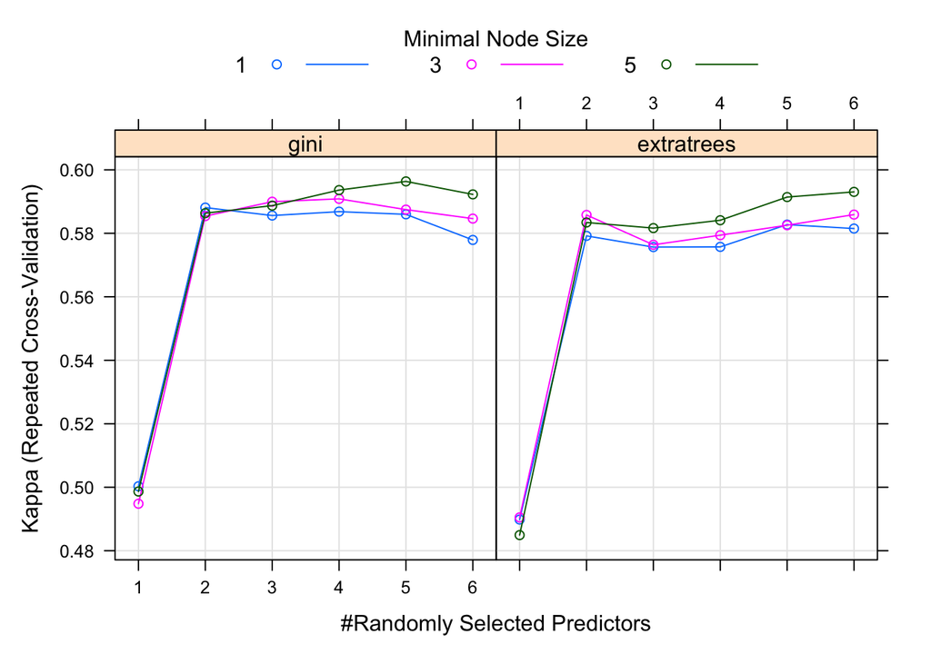

```r
rf_tune <- train(
  survived_flag ~ .,
  data = titanic_train,
  method = "ranger",
  metric = "Kappa",
  num.trees = 1000,
  importance = "impurity",
  tuneGrid = tune_grid,
  trControl = control
)

plot(rf_tune)
```

```r
rf_tune
```

```
## Random Forest
##
## 570 samples
##   6 predictor
##   2 classes: 'No', 'Yes'
##
## No pre-processing
## Resampling: Cross-Validated (5 fold, repeated 10 times)
## Summary of sample sizes: 456, 455, 456, 457, 456, 456, ...
## Resampling results across tuning parameters:
##
##   mtry  splitrule   min.node.size  Accuracy   Kappa
##   1     gini        1              0.7754524  0.5003169
##   1     gini        3              0.7728038  0.4948110
##   1     gini        5              0.7745705  0.4986533
```

[output cut: 37 more lines]